# Applying Random Forest Methods on Predictors for Diabetes

## Introduction to Random Forest

- Random forest is an ensemble learning method composed of multiple decision trees.
- Random forest is used in a variety of applications such as ecology, medicine, astronomy, agriculture, traffic, and bioinformatics.
- Random forest improves on the decision tree method for classification (predicting a class label) and regression (predicting a continuous value).
- The method is attributed to Dr. Leo Breiman of the University of California at Berkeley.

## What We Will Show

- We will use a health questionnaire dataset to predict diabetes.
- We seek to reduce the number of survey questions (and variables) and focus on the most influential predictors of diabetes.
- We accomplish this by calculating the variable importance using the Gini impurity value.
- The most important variables impacting Diabetes were found to be BMI, General Health, High Blood Pressure, Age, Income, and Physical Health.

## Background - Decision Trees

- Decision trees are used for prediction and classification in a variety of artificial intelligence and machine learning tasks.
- Decision trees divide data by fields, creating subsets called nodes. Cutoffs are applied based on statistics (de Ville 2013).
- Improvements to decision tree classifiers reduce bias and variance.
  - Resampling training data and using multiple trees.
  - Bootstrap aggregating (bagging) and AdaBoost (adaptive boosting).
  - Multi-tree solutions: voting over multiple trees and using split methods of alternative splits and oblique splits (Breiman 1996).
- Random Forest is an ensemble method (uses several methods to solve a problem).
- Diversity among methods is indicated by methods making different errors, leading to improvements in classifications (Fawagreh, Gaber, and Elyan 2014).

## Origins of Random Forest

- A study by Dietterich (Dietterich 2000) compared a method of randomizing the split of C4.5 decision trees with AdaBoost and Bagging methods on 33 datasets.
- The effect of randomization lead to a diverse set of decision trees.
- The performance with “noise” or changed class labels for various percentages of the data was also tested since it was noted that AdaBoost did not do well with such noise, due to amplifying the effect of the noise.
- Breiman’s paper, “Random Forests”, (Breiman 2001) is attributed to be the first mention and description of the random forest technique.
- Random Forest classifiers are based on decision trees which have been generated from random subsets of the variables. The final classification is determined by majority vote of the decision trees.

## Uses of Random Forest

- Classification (predicting a class label) or regression (predicting a continuous value).
- Performs well with noisy data, since it does not weight the data and does not amplify the weight of noise.
- Does not overfit data due to the randomness of the selected variables used for the prediction.
- The “out of bag” estimate for a class label is the estimate using trees that do not contain the class label, and it is a good estimate of overall error rate.
- Random forests can have similar error rates as another machine learning algorithm, AdaBoost. AdaBoost is “equivalent to fitting an additive logistic regression model by a stage-wise estimation procedure,” and successful because of imparting diversity to the ensemble, but with a tradeoff in accuracy (Rodriguez, Kuncheva, and Alonso 2006).

## Improvements and Expansions to Random Forest

- Random forest extensions include non-parametric tests of significance, weighted voting, dynamic integration, weighted random sampling, online random forest (streamed / partial data), and genetic algorithms (Fawagreh, Gaber, and Elyan 2014).
- Random forest is sensitive to tuning parameters such as number of variables selected and number of trees (Verikas, Gelzinis, and Bacauskiene 2011).
- Modifications can include how individual trees are built, the construction of datasets, and how individual predictions are coalesced into one prediction (Boulesteix et al. 2012).

## Parameters

- Predictor selection is important.
- If the number of trees increases with the number of predictors, the randomization process will lead to predictors having a good chance to be selected.
- The number of predictors is important in order to moderate the effects of strong and weak predictors, as some predictors are not informative.
- The size of trees is determined by the splitting criteria.
- The size of the leaves is another parameter wherein good predictors could be overlooked if the leaf size threshold is too small.
- To avoid bias, it is recommended to perform sampling without replacement, and sample a certain number of observations from multiple classes (Boulesteix et al. 2012).

## Using PCA to Enhance

- A study by Gardener et. al (Gardner and Chia-Tien Lo 2021) combined Random Forest methodology with Principal Component Analysis (PCA) to improve precision.
- PCA is used to create new combination vectors for dependent features in this case (automate the creation of the new features).
- The random forest technique would then incorporate the new features, allowing the single split of a new variable that combines multiple features.
- Another improvement is the fact that each tree has unique features due to the PCA algorithm being applied on each tree, so the trees are less correlated, which has been shown to increase accuracy.

## Applications

- As the size of datasets increases (defined by the number of variables exceeding the number of observations), the performance of statistical methods decline and machine learning methods are preferred (Verikas, Gelzinis, and Bacauskiene 2011).
- Random forests have been used in several studies related to biology and medicine, where there is usually a relationship between response and predictor variables and sometimes strong correlations between predictors.
- Other studies have found good performance in areas such as predicting customer churn, fraud detection, identifying bacteria and fish, and identifying eye disease (Verikas, Gelzinis, and Bacauskiene 2011).

## Applications

- Random forest has been used to predict students’ major and completion status (Beaulac and Rosenthal 2019), and predict progression from MCI (mild cognitive impairment) to AD (Alzheimer’s disease) (Moore, Lyons, and Gallacher 2019).
- An additional study addressed determining risk factors for diabetes, a disease affecting 425 million adults where chronic high blood sugar has effects such as damaging blood vessels, organs, nerves, and other complications (Lin, Ji, and Pei 2019).
- Next we will discuss the methodology of random forest.

## Methods

- Create a number of decision trees that use a random subset of features for the prediction.
- The data values are run through all of the decision trees that were created for each row.
- The value for the class label is predicted based on the majority prediction of the trees (Breiman 2001).
- The randomness of the features allows some decision tree models to be created with weaker predictive features, which increases model variability.
- Model variability is a key component for greater predictive accuracy, allowing weaker variables to still have some effect (Dietterich 2000).
- The criteria for splitting is generally to minimize Gini Impurity.
  - Low Gini Impurity implies that the items are more homogeneous (of the same class label).

## Gini Impurity

Gini Impurity of a single node
$$Gini(D) = 1 - \sum_{i = 1}^{c} p(y_i)^2$$
where $p(y_i)$ is the probability that a sample belongs to class i, and c is the number of classes. As the sum of the probability squared approaches 1, Gini Impurity approaches 0. Impurity is 0 when all of the items are of the same class.

Gini Impurity of a node with child nodes (Robnik-Šikonja 2004)
$$Gini(A_i) = -\sum_{i = 1}^{c} p(y_i)^2 + \sum_{j = 1}^{m_i}p(v_{i,j})\sum_{i = 1}^{c}p(y_i|v_{i,j})^2$$

## Decision Tree Example

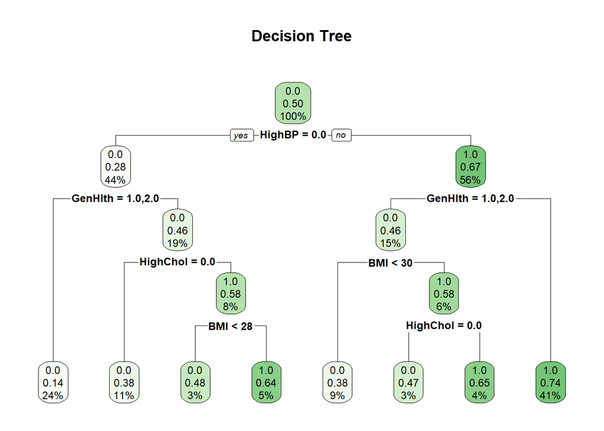

This decision tree shows a split on the HighBP field, with 44% having Yes on the left, and 56% having No on the right. The lowest level shows the classification.

## Random Forest Algorithm

The algorithm for random Random Forest is:

1. At the current node, randomly select p features from available features D. The number of features p is usually much smaller than the total number of features D.
2. Compute the best split point for tree k using the specified splitting metric (Gini Impurity, Information Gain, etc.) and split the current node into daughter nodes and reduce the number of features D from this node on.
3. Repeat steps 1 to 2 until either a maximum tree depth l has been reached or the splitting metric reaches some extrema.
4. Repeat steps 1 to 3 for each tree k in the forest.
5. Vote or aggregate on the output of each tree in the forest.

**Source: (Dimitriadis and Liparas 2018)**

## Out Of Bag Error Rate

- The error rate for a random forest model can be calculated using a method called the “out of bag” estimate.
- Calculated by using prediction error rate for decision tree models in the random forest that do not contain the class label (Breiman 2001).
- Because the error rate can be approximated in this way, the data does not necessarily have to be split into test and train datasets as in other machine learning models (Breiman 2001).
- Regardless of that, splitting into test and train datasets continues to be a best practice, especially if comparing/using the random forest method with other machine learning methods.

## Sample Random Forest Code in R

Sample code for Random Forest in R:

```
  #include randomForest library
  library(randomForest)

  #load data into dataframe df  ...

  #create random forest using model, data frame df, and number of trees ntree
  diabetes.forest <- randomForest(Diabetes_binary ~ HighBP + GenHlth + BMI + HighChol,
    data=df, ntree=300)

  #votes (probability per row) is in the random forest model votes field
  diabetes.forest$votes
```

Sample Probabilities By Row

| Row | Yes | No |
| --- | --- | --- |
| 1 | 0.136842105 | 0.863157895 |
| 2 | 0.595041322 | 0.404958678 |
| 3 | 0.990654206 | 0.009345794 |

## Data and Visualization

Data Source: [Diabetes Health Indicators Dataset (Kaggle)](https://www.kaggle.com/datasets/alexteboul/diabetes-health-indicators-dataset)

- This data set focuses on diabetes, a chronic health condition affecting millions of people worldwide that can cause serious complications and lower quality of life.
- There is a need to predict an individual’s risk of developing diabetes for preventative measures to improve outcomes (Teboul 2021).
- This data is a subset of data from the The Behavioral Risk Factor Surveillance System (BRFSS), a survey conducted by the CDC to examine Americans’ responses in the areas of health behaviors and conditions.
  - The data includes 21 feature variables and 70,692 survey responses.
  - The response variable is whether or not an individual has diabetes (indicated by 0 for no or 1 for pre-diabetes or diabetes).
  - The data has a 50-50 binary split, meaning the data is evenly split between having diabetes or not (Teboul 2021).

## Data Set Variables

| Data Field | Description of Data | Range of Values |
| --- | --- | --- |
| HighBP | Told by a healthcare professional they have high blood pressure. | (0, 1) |
| HighChol | Told by a healthcare professional they have high cholesterol. | (0, 1) |
| CholCheck | Cholesterol check within past 5 years. | (0, 1) |
| BMI | Body Mass Index | (12, 98) |
| Smoker | Smoked at least 100 cigarettes lifetime. | (0, 1) |
| Stroke | Told by a healthcare professional they have had a stroke. | (0, 1) |
| HeartDiseaseorAttack | Reported having heart disease or heart attack. | (0, 1) |

## Data Set Variables (continued)

| Data Field | Description of Data | Range of Values |
| --- | --- | --- |
| PhysActivity | Physical activity/exercise in past 30 days. | (0, 1) |
| Fruits | Consume fruit 1+ times daily. | (0, 1) |
| Veggies | Consume vegetables 1+ times daily. | (0, 1) |
| HvyAlcoholConsump | Heavy drinkers (adult men having more than 14 drinks per week and adult women having more than 7 drinks per week) | (0, 1) |
| AnyHealthcare | Reported having any kind of health insurance/healthcare coverage. | (0, 1) |
| NoDocbcCost | Reported needing to see a doctor in the past year, but unable because of cost. | (0, 1) |
| GenHlth | Statement of general health. | (1, 5) |

## Data Set Variables (continued)

| Data Field | Description of Data | Range of Values |
| --- | --- | --- |
| MentHlth | Statement of mental health in past 30 days (not good). | (0, 30) |
| PhysHlth | Statement of physical health in past 30 days (not good). | (0, 30) |
| DiffWalk | Difficulty walking up or down stairs. | (0, 1) |
| Sex | Sex/gender | (0, 1) |
| Age | Age group | (1, 13) |
| Education | Highest grade completed. | (1, 6) |
| Income | Annual household income. | (1, 8) |

## Data Visualization Charts

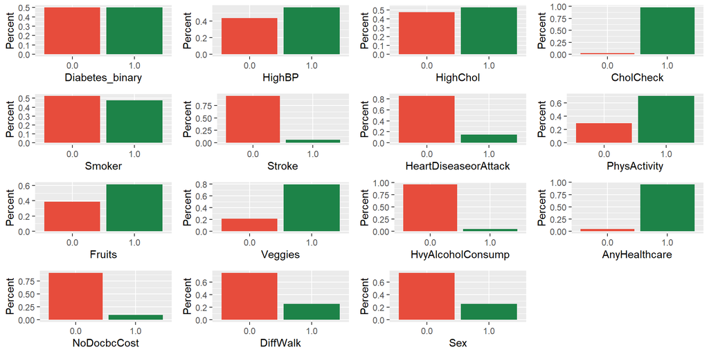

Summary of the binary variables in the data set.

## Data Visualization Charts (continued)

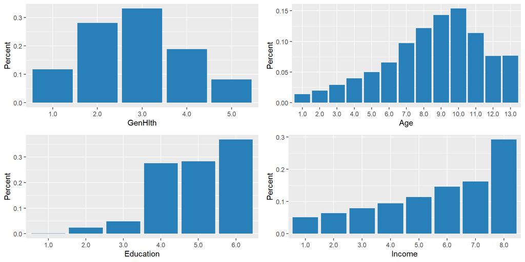

Summary of the multi-valued variables in the data set.

## Statistical Modeling

- Our goal: Determine the level of predictive accuracy of the variables in the data set while using the random forest method.
- Our steps taken:
  - Analyze variable importance measures to find the most important questions in the Behavioral Risk Factor Surveillance System (BRFSS) survey.
  - Create a version of the BRFSS survey with less questions.
  - Gauge accuracy of the reduced version of the BRFSS survey, with the idea that a reduced version will increase future participation.
  - Our initial random forest analysis will use default parameters.
  - We will use the **ranger** package in R to implement a fast version of random forest.
  - We classify the Diabetes Binary field using all of the remaining fields in the data set.
  - We output the variable importance using Gini impurity as the importance measure.

## Random Forest Default Parameters

**Code: Random Forest With Default Parameters**

```r
#create actual random forest with full list of variables for analysis
diabetes.forest <- ranger(Diabetes_binary ~ ., data=df, importance = 'impurity')
print(diabetes.forest)
```

```
Ranger result

Call:
 ranger(Diabetes_binary ~ ., data = df, importance = "impurity")

Type:                             Classification
Number of trees:                  500
Sample size:                      70692
Number of independent variables:  21
Mtry:                             4
Target node size:                 1
Variable importance mode:         impurity
Splitrule:                        gini
OOB prediction error:             25.36 %
```

## Importance Measures Result

**Code: Importance Measures Chart**

```r
#create vi object for variable importance graph
vi_values <- vi(diabetes.forest)
#create variable importance graph
vip(vi_values, aesthetics = list(fill="#2980B9"))
```

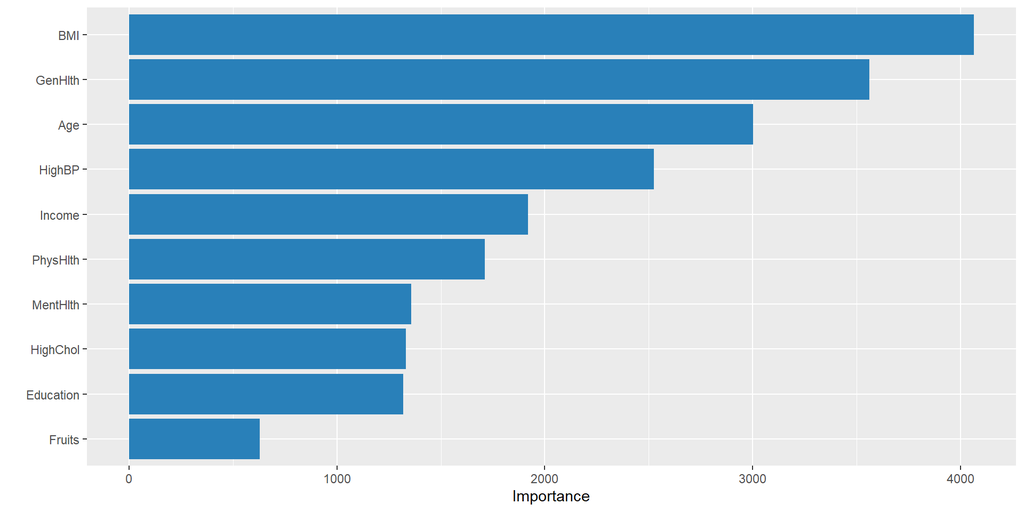

- The most important variables impacting Diabetes were found to be BMI, General Health, Age, and High Blood Pressure.

## Hyperparameter Tuning

- Random Forest and other machine learning methods require hyperparameter tuning to obtain optimal settings for variables.
- Hyperparameters are parameters that can vary and different values can have a large effect on the model.
- In this example a grid search is used to find the optimal number of variables to use for the split, which uses the “mtry” parameter.
- For speed and efficiency, a stratified sample of 10% of the dataset was used for this algorithm. Stratified means that an equal number of the target class (e.g. Diabetes_binary) are present in the sample.

## Tune Random Forest

**Code: Tune Random Forest**

```r
#split data and stratify on class label
parts <- splitTools::partition(df$Diabetes_binary, p=c(sample = 0.1, remainder = 0.9))
df.sample <- df[parts$sample,]

#set the metric to be used for tuning
metric <- "Accuracy"

#setup control settings for caret train(tune) call
control <- trainControl(method="repeatedcv", number=5, repeats=3, search="grid")
#set up train (tune) parameters
tunegrid <- expand.grid(.mtry=c(1:10), .splitrule='gini', .min.node.size=1)
#call to caret train(tune) using sample of data
rf_gridsearch <- train(Diabetes_binary~., data=df.sample, method="ranger", metric=metric, tuneGrid=tunegrid, trControl=control)

#plot results for parameter tuning
plot(rf_gridsearch)
```

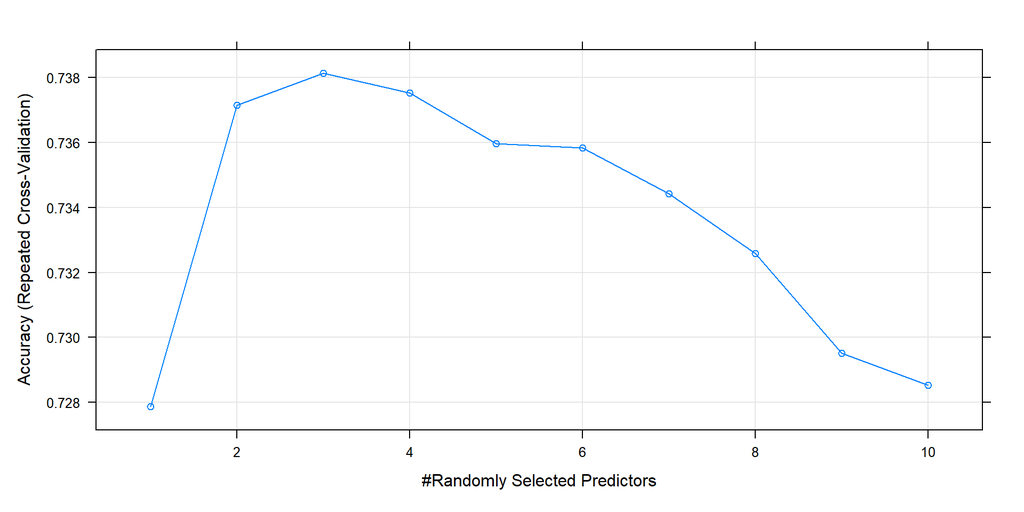

- This plot shows that the optimal value for number of variables to split at each node peaks at 3 and declines from there.
- The number of trees was tuned manually by testing with 500 to 3000 trees in increments of 500. It was found that about 2000 trees is optimal for this data set.

## Random Forest Tuned

**Code: Random Forest Tuned**

```r
#now try with specific parameters found by tuning
diabetes.forest <- ranger(Diabetes_binary ~ ., data=df,
                          mtry=3, num.trees=2000, verbose = FALSE)
print(diabetes.forest)
```

```
Ranger result

Call:
 ranger(Diabetes_binary ~ ., data = df, mtry = 3, num.trees = 2000,      verbose = FALSE)

Type:                             Classification
Number of trees:                  2000
Sample size:                      70692
Number of independent variables:  21
Mtry:                             3
Target node size:                 1
Variable importance mode:         none
Splitrule:                        gini
OOB prediction error:             25.12 %
```

- The tuned model has a prediction error of 25.1% for a higher accuracy of 74.9%.

## Random Forest Prediction

- Next we want to illustrate how to use prediction with random forest.
- For prediction we first split the data into train (70%) and test (30%) sets.
- Next the model is fit on the train set, leaving the test set as “unseen” data.
- Finally the model is used to predict on the test set and the true value of the test set is compared to the predicted value.

**Code: Random Forest Model Fit & Prediction**

```r
#split data and stratify on class label
parts <- splitTools::partition(df$Diabetes_binary, p=c(train = 0.7, test = 0.3))
df.train <- df[parts$train,]
df.test <- df[parts$test,]

#train rf with train set
diabetes.forest <- ranger(Diabetes_binary ~ ., data=df.train,
                          mtry=3, num.trees=2000, verbose = FALSE)

#predict using test set
preds <- predict(diabetes.forest, data = df.test, seed=randseed)
```

## Confusion Matrix

- Accuracy can be assessed using a confusion matrix.
- A confusion matrix calculates True Positive, False Positive, True Negative, and False Negative values.
- True Positive (TP) is a sample classified as positive which is in fact positive, False Positive (FP) a positive when it is in fact negative, True Negative (TN) a negative which indeed is negative, and False Negative (FN) a negative when it is in fact positive.
- From these values, the accuracy can be obtained as:

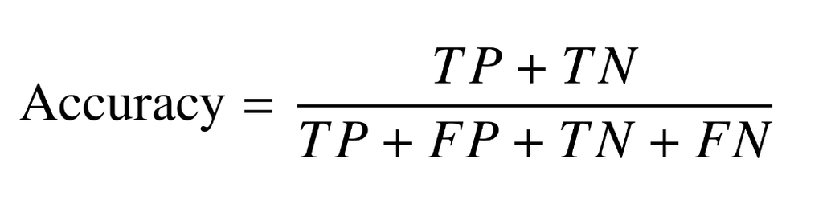

(Kundu 2022)

- This allows us a deeper understanding of the model, as we can easily see the model’s accuracy as it relates to positive and negative classifications.

## Show Predictive Accuracy

**Code: Confusion Matrix Pie Chart**

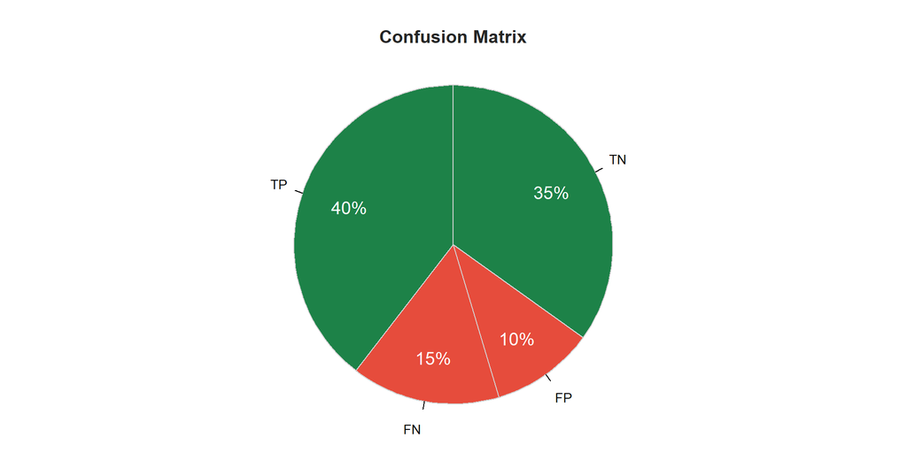

```r
#create confusion matrix of prediction vs actual on test set
confusion.test <- confusionMatrix(data=df.test$Diabetes_binary, reference=preds$predictions)

#create dataframe to use for the chart
cf <- data.frame(cfm = confusion.test$table)
#add percentage field
cf <- cf %>%  mutate(cfm.Percent = cfm.Freq / sum(cfm.Freq))
#add labels for TN, FN, TP, FP
cf <- cf %>%  mutate(cfm.Label =
                       case_when(cfm.Prediction == "0.0" & cfm.Reference == "0.0" ~ "TN",
                                 cfm.Prediction == "0.0" & cfm.Reference == "1.0" ~ "FN",
                                 cfm.Prediction == "1.0" & cfm.Reference == "1.0" ~ "TP",
                                 cfm.Prediction == "1.0" & cfm.Reference == "0.0" ~ "FP"))

#add color field to go with the labels - green is good and red is bad
cf <- cf %>%  mutate(cfm.Label.Color =
                       case_when(cfm.Prediction == "0.0" & cfm.Reference == "0.0" ~ "#1D8348",
                                 cfm.Prediction == "0.0" & cfm.Reference == "1.0" ~ "#E74C3C",
                                 cfm.Prediction == "1.0" & cfm.Reference == "1.0" ~ "#1D8348",
                                 cfm.Prediction == "1.0" & cfm.Reference == "0.0" ~ "#E74C3C"))
#tried to set it to output in the order I wanted but it seems to have it's own order
#this did nothing for the sort order of the output chart
#cf <- cf %>% mutate(cfm.Label = factor(cfm.Label, levels = c("TN", "FN", "TP", "FP")))

#output the chart
PieChart(x = cfm.Label, y = cfm.Percent, hole = 0, values = "%", data = cf,
         clockwise = T, quiet = T, fill = cf$cfm.Label.Color,  values_size = 1.2,
         main = "Confusion Matrix")
```

- Our model’s accuracy is approximately 75% as illustrated in the pie chart.
- True Positive (TP) and True Negative (TN) account for 75% of the model.
- False Positive (FP) and False Negative (FN) account for 25% of the model.

## Questionnaire Reduction

- The goal is to reduce the number of questions needed on the Behavioral Risk Factor Surveillance System (BRFSS) and maintain high accuracy.
- We select the top 4 questions and run the classification to gauge accuracy.

**Code: Reduced Parameters**

```r
#use reduced list of parameters found by assessing variable importance
diabetes.forest.reduced <- ranger(Diabetes_binary ~ BMI + GenHlth + HighBP + Age, data=df)
print(diabetes.forest.reduced)
```

```
Ranger result

Call:
 ranger(Diabetes_binary ~ BMI + GenHlth + HighBP + Age, data = df)

Type:                             Classification
Number of trees:                  500
Sample size:                      70692
Number of independent variables:  4
Mtry:                             2
Target node size:                 1
Variable importance mode:         none
Splitrule:                        gini
OOB prediction error:             26.00 %
```

- This result shows a survey with 4 questions still has 74.0% accuracy (prediction error 26.0%). Amazing!

## Conclusion

- We discussed the origins and background of the Random Forest method, which stems from uses of multiple decision trees on the same data set using different sets of variables or fields.
- We highlighted some previous applications of Random Forest, and showed the methodology and algorithm.
- We were able to use the Random Forest method to classify the test data set into Diabetic and Non-Diabetic with approximately 74.9% accuracy (prediction error 25.1%).
- We demonstrated hyperparameter tuning for Random Forest for the mtry parameter and manually tuned the number of trees.
- We also demonstrated using random forest for prediction of unseen data and showed the method of gauging prediction accuracy comparing the true value with the predicted value on the unseen test data.

## Conclusion (continued)

### Questions?

## References

Beaulac, Cédric, and Jeffrey S. Rosenthal. 2019. “Predicting University Students’ Academic Success and Major Using Random Forests.” *Research in Higher Education* 60 (7): 1048–64. http://www.jstor.org/stable/45217777.

Boulesteix, Anne-Laure, Silke Janitza, Jochen Kruppa, and Inke R. König. 2012. “Overview of Random Forest Methodology and Practical Guidance with Emphasis on Computational Biology and Bioinformatics.” *WIREs Data Mining and Knowledge Discovery* 2 (6): 493–507. https://doi.org/10.1002/widm.1072.

Breiman, Leo. 1996. “Bagging Predictors.” *Machine Learning* 123–140.

———. 2001. “Random Forests.” *Machine Learning* 45: 5–32.

de Ville, Barry. 2013. “Decision Trees.” *WIREs Computational Statistics* 5 (6): 448–55. https://doi.org/10.1002/wics.1278.

Dietterich, Thomas G. 2000. “An Experimental Comparison of Three Methods for Constructing Ensembles of Decision Trees: Bagging, Boosting, and Randomization.” *Machine Learning* 40: 139–57.

Dimitriadis, S. I., and D. Liparas. 2018. “Alzheimer’s Disease Neuroimaging Initiative. How Random Is the Random Forest? Random Forest Algorithm on the Service of Structural Imaging Biomarkers for Alzheimer’s Disease: From Alzheimer’s Disease Neuroimaging Initiative (ADNI) Database.” *Neural Regeneration Research* 13 (6): 962–70. https://doi.org/10.4103/1673-5374.233433.

Fawagreh, K., M. Gaber, and E. Elyan. 2014. “Random Forests: From Early Developments to Recent Advancements.” *Systems Science & Control Engineering* 2 (9): 602–9.

Gardner, Charles, and Dan Chia-Tien Lo. 2021. “PCA Embedded Random Forest,” 1–6. https://doi.org/10.1109/SoutheastCon45413.2021.9401949.

Kundu, Rohit. 2022. “Confusion Matrix: How to Use It & Interpret Results.” https://www.v7labs.com/blog/confusion-matrix-guide.

Lin, Shaofu, Wei Ji, and Jiangtao Pei. 2019. “A Method for Selecting Diabetes Features Based on Random Forest.” *Journal of Physics: Conference Series* 1237 (2). https://www.proquest.com/docview/2566217454.

Moore, P. J., T. J. Lyons, and J. Gallacher. 2019. “Random Forest Prediction of Alzheimer’s Disease Using Pairwise Selection from Time Series Data.” *PLoS ONE* 14 (2). https://journals.plos.org/plosone/article?id=10.1371/journal.pone.0211558.

Robnik-Šikonja, Marko. 2004. “Improving Random Forests.” In *Machine Learning: ECML 2004*, 359–70. Springer Berlin Heidelberg. https://doi.org/10.1007/978-3-540-30115-8_34.

Rodriguez, Juan J., Ludmilla I. Kuncheva, and Carlos J. Alonso. 2006. “Rotation Forest: A New Classifier Ensemble Method.” *IEEE Transactions On Pattern Analysis And Machine Intelligence* 28 (10): 1619–30.

Teboul, Alex. 2021. “Diabetes Health Indicators Dataset.” https://www.kaggle.com/datasets/alexteboul/diabetes-health-indicators-dataset/.

Verikas, A., A. Gelzinis, and M. Bacauskiene. 2011. “Mining Data with Random Forests: A Survey and Results of New Tests.” *Pattern Recognition* 44 (2): 330–49. https://doi.org/10.1016/j.patcog.2010.08.011.